# Greenspotted Rockfish

*Sebastes chlorostictus*

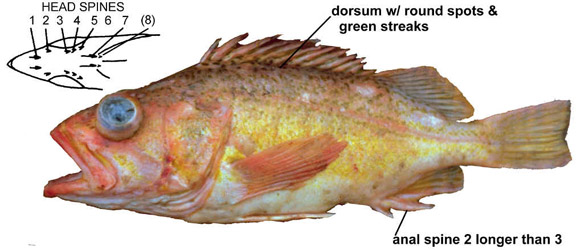

**Body color:** Orange to yellow-pink w/ round, green spots and streaks on back and upper sides; 3 to 5 whitish blotches, bordered w/ light pink or orange, on back; fins yellow-pink.

**Peritoneum color:** gray to dark **Shape between eyes:** concave

**Counts:** D:XII,11-15, Ar:5-7, P1:16-18, GR:31-36, LLp:35-43, LLs:49-52, V:26-27

**Occurence:** Washington - Baja California

**Depth:** 201 meters **Size:** 51 cm **Species code:** 30130

**Similar species:**

- *Rosethorn rockfish* - body typically w/ faint green spots and streaks; pectoral rays typically 16 (17 in Greenspotted RF); gillrakers typically 28-31 (31-36 in Greenspotted RF)
- *Rosy rockfish* - body red, mottled w/ purple, typically w/ purple band on nape, w/out green spots and streaks
- *Pinkrose rockfish* - body uniform pinkish-red,w/out green spots and streaks
- *Swordspine rockfish* - body w/out green spots or streaks; mottled w/ red or purple; symphyseal knob prominent (absent in Greenspotted RF); lower jaw projects beyond upper jaw (jaws equal in Greenspotted RF); gillrakers typically 35-40 (31-36 in Greenspotted RF)
- *Pink rockfish and Greenblotched rockfish* - body w/ irregular greenish blotches and wavy lines on back (round spots in Greenspotted RF)
- *Freckled rockfish* - prominent knobs on upper jaw (absent in Greenspotted RF)

Back to Group

**Corrections:** If you see mistakes or want to suggest changes, please create an [issue](https://github.com/zoyafuso-NOAA/RACE_Survey_App/issues) on the source repository or

*reach out to Liz Dawson (Liz.Dawson AT noaa.gov).*